# HUGEN 2072 Project 2

```r
#   Extract the metadata so that it can be updated

meta_temp <- getMetadata(snp_annodf_temp)
meta_temp
```

```
##                                                                                                        labelDescription
## snpID                                                                                        unique integer ID for SNPs
## chromosome    integer code for chromosome: 1:22=autosomes, 23=X, 24=pseudoautosomal, 25=Y, 26=Mitochondrial, 27=Unknown
## position                                                                    base pair position on chromosome (build 36)
## rsID                                                                                                      RS identifier
## alleleA                                                                                                         alelleA
## alleleB                                                                                                         alleleB
## BeadSetID                                                                                      BeadSet ID from Illumina
## IntensityOnly                                                              1=no genotypes were attempted for this assay
## tAA                                                                                           mean theta for AA cluster
## tAB                                                                                           mean theta for AB cluster
## tBB                                                                                           mean theta for BB cluster
## rAA                                                                                               mean R for AA cluster
## rAB                                                                                               mean R for AB cluster
## rBB                                                                                               mean R for BB cluster
## dummy                                                                                                              <NA>
```

```r
#   Add a new row titled "dummy" with an appropriate labelDescription (note that
#   the metadata is a data frame with named rows but one column)

meta_temp["dummy", "labelDescription"] <- "This is a dummy variable"

#   Finally, replace the old metadata with the new metadata

varMetadata(snp_annodf_temp) <- meta_temp

#   Look at the data and metadata to make sure there the dummy variable has been
#   added

head(getAnnotation(snp_annodf_temp))
```

```
##    snpID chromosome position      rsID alleleA alleleB  BeadSetID IntensityOnly
## 1 999447         21 13733610 rs3132407       A       G 1185447327             1
## 2 999465         21 13852569 rs2775671       T       C 1169708488             0
## 3 999493         21 14038583 rs2775018       T       C 1192445330             0
## 4 999512         21 14136579 rs3115511       T       C 1149617207             0
## 5 999561         21 14396024 rs2822404       T       C 1149961944             0
## 6 999567         21 14404476 rs1556276       A       G 1149617207             0
##           tAA       tAB       tBB       rAA       rAB       rBB dummy
## 1 0.013743570 0.3290431 0.9184624 1.5622030 1.5927530 1.6142590     1
## 2 0.063259460 0.5440393 0.9796721 0.4431986 0.4431986 0.4431986     2
## 3 0.001315146 0.2623954 0.5362323 2.6349810 2.3149340 2.0012760     3
## 4 0.011004820 0.5692499 0.9846884 0.8781826 0.9453412 0.8209958     4
## 5 0.040206810 0.5691788 0.9902423 1.0941700 1.1270790 0.9898759     5
## 6 0.030895730 0.6842008 0.9837771 0.5954081 0.7681253 0.7900150     6
```

```r
getMetadata(snp_annodf_temp)
```

```
##                                                                                                        labelDescription
## snpID                                                                                        unique integer ID for SNPs
## chromosome    integer code for chromosome: 1:22=autosomes, 23=X, 24=pseudoautosomal, 25=Y, 26=Mitochondrial, 27=Unknown
## position                                                                    base pair position on chromosome (build 36)
## rsID                                                                                                      RS identifier
## alleleA                                                                                                         alelleA
## alleleB                                                                                                         alleleB
## BeadSetID                                                                                      BeadSet ID from Illumina
## IntensityOnly                                                              1=no genotypes were attempted for this assay
## tAA                                                                                           mean theta for AA cluster
## tAB                                                                                           mean theta for AB cluster
## tBB                                                                                           mean theta for BB cluster
## rAA                                                                                               mean R for AA cluster
## rAB                                                                                               mean R for AB cluster
## rBB                                                                                               mean R for BB cluster
## dummy                                                                                          This is a dummy variable
```

```r
#   Remove the temp files

rm(snp_annodf_temp, snp_data_temp, meta_temp)
```

Now we use `GdsGenotypeReader()` and `GdsIntensityReader()` to open the gds files that contain the array data. Then use `GenotypeData()` and `IntensityData()` to combine them with the SNP and sample annotation, since the functions we’ll be using later require this information to be “packaged” together.

```r
#   Get the genotypes from a gds file

genofile <-
  system.file("extdata", "illumina_geno.gds", package = "GWASdata")
gds_geno <- GdsGenotypeReader(genofile)

#   Combine the genotypes with the sample and SNP annotation

genoData <-
  GenotypeData(gds_geno, snpAnnot = snpAnnot, scanAnnot = scanAnnot)
genoData
```

```
## An object of class GenotypeData
##  | data:
## File: /software/rhel9/manual/install/r/4.5.0/lib64/R/library/GWASdata/extdata/illumina_geno.gds (94.0K)
## +    [  ]
## |--+ sample.id   { Int32 77 ZIP(42.2%), 130B }
## |--+ snp.id   { Int32 3300 ZIP(38.5%), 5.0K }
## |--+ snp.chromosome   { UInt8 3300 ZIP(1.15%), 38B } *
## |--+ snp.position   { Int32 3300 ZIP(91.0%), 11.7K }
## |--+ snp.rs.id   { VStr8 3300 ZIP(38.4%), 12.5K }
## |--+ snp.allele   { VStr8 3300 ZIP(9.49%), 1.2K }
## \--+ genotype   { Bit2 3300x77, 62.0K } *
##  | SNP Annotation:
## An object of class 'SnpAnnotationDataFrame'
##   snps: 1 2 ... 3300 (3300 total)
##   varLabels: snpID chromosome ... rBB (14 total)
##   varMetadata: labelDescription
##  | Scan Annotation:
## An object of class 'ScanAnnotationDataFrame'
##   scans: 1 2 ... 77 (77 total)
##   varLabels: scanID subjectID ... file (13 total)
##   varMetadata: labelDescription
```

```r
#   Get the intensity data from a gds file

qxyfile <-
  system.file("extdata", "illumina_qxy.gds", package = "GWASdata")
gds_qxy <- GdsIntensityReader(qxyfile)

#   Combine with the sample and SNP annotation

qxyData <-
  IntensityData(gds_qxy, snpAnnot = snpAnnot, scanAnnot = scanAnnot)
qxyData
```

```
## An object of class IntensityData
##  | data:
## File: /software/rhel9/manual/install/r/4.5.0/lib64/R/library/GWASdata/extdata/illumina_qxy.gds (1.0M)
## +    [  ]
## |--+ sample.id   { Int32 77 ZIP(42.2%), 130B }
## |--+ snp.id   { Int32 3300 ZIP(38.5%), 5.0K }
## |--+ snp.chromosome   { UInt8 3300 ZIP(1.15%), 38B } *
## |--+ snp.position   { Int32 3300 ZIP(91.0%), 11.7K }
## |--+ snp.rs.id   { VStr8 3300 ZIP(38.4%), 12.5K }
## |--+ quality   { Float32 3300x77 ZIP(4.93%), 48.9K }
## |--+ X   { Float32 3300x77 ZIP(50.3%), 498.8K }
## \--+ Y   { Float32 3300x77 ZIP(49.4%), 490.5K }
##  | SNP Annotation:
## An object of class 'SnpAnnotationDataFrame'
##   snps: 1 2 ... 3300 (3300 total)
##   varLabels: snpID chromosome ... rBB (14 total)
##   varMetadata: labelDescription
##  | Scan Annotation:
## An object of class 'ScanAnnotationDataFrame'
##   scans: 1 2 ... 77 (77 total)
##   varLabels: scanID subjectID ... file (13 total)
##   varMetadata: labelDescription
```

```r
#   Get the BAF/LRR data from a gds file

blfile <-
  system.file("extdata", "illumina_bl.gds", package = "GWASdata")
gds <- GdsIntensityReader(blfile)

#   Combine the BAF/LRR data with the sample and SNP annotation

blData <-
  IntensityData(gds, snpAnnot = snpAnnot, scanAnnot = scanAnnot)
blData
```

```
## An object of class IntensityData
##  | data:
## File: /software/rhel9/manual/install/r/4.5.0/lib64/R/library/GWASdata/extdata/illumina_bl.gds (1.1M)
## +    [  ]
## |--+ sample.id   { Int32 77 ZIP(42.2%), 130B }
## |--+ snp.id   { Int32 3300 ZIP(38.5%), 5.0K }
## |--+ snp.chromosome   { UInt8 3300 ZIP(1.15%), 38B } *
## |--+ snp.position   { Int32 3300 ZIP(91.0%), 11.7K }
## |--+ snp.rs.id   { VStr8 3300 ZIP(38.4%), 12.5K }
## |--+ BAlleleFreq   { Float32 3300x77 ZIP(40.9%), 405.8K }
## \--+ LogRRatio   { Float32 3300x77 ZIP(68.2%), 676.6K }
##  | SNP Annotation:
## An object of class 'SnpAnnotationDataFrame'
##   snps: 1 2 ... 3300 (3300 total)
##   varLabels: snpID chromosome ... rBB (14 total)
##   varMetadata: labelDescription
##  | Scan Annotation:
## An object of class 'ScanAnnotationDataFrame'
##   scans: 1 2 ... 77 (77 total)
##   varLabels: scanID subjectID ... file (13 total)
##   varMetadata: labelDescription
```

## Part 0 - Report

Using the functions introduced above to help you, briefly describe the dataset in a few sentences. Answer the following questions. Whatever code you use to help answer these questions can go in the empty chunk that follows.

- What is the difference between the scanID and subjectID variables? Why are they both provided?
- How many families are represented, and how many samples are from each family?
- How many samples are of each sex?
- How many samples are from each population group?
- How many samples are there? How many people did they come from?
- How many SNPs are there?
- Which chromosomes are represented? How many SNPs are on each?

```r
library(tidyverse)
# Your code goes here
snp <- pData(snpAnnot)
scan <- pData(scanAnnot)
head(snp)
```

```
##    snpID chromosome position      rsID alleleA alleleB  BeadSetID IntensityOnly
## 1 999447         21 13733610 rs3132407       A       G 1185447327             1
## 2 999465         21 13852569 rs2775671       T       C 1169708488             0
## 3 999493         21 14038583 rs2775018       T       C 1192445330             0
## 4 999512         21 14136579 rs3115511       T       C 1149617207             0
## 5 999561         21 14396024 rs2822404       T       C 1149961944             0
## 6 999567         21 14404476 rs1556276       A       G 1149617207             0
##           tAA       tAB       tBB       rAA       rAB       rBB
## 1 0.013743570 0.3290431 0.9184624 1.5622030 1.5927530 1.6142590
## 2 0.063259460 0.5440393 0.9796721 0.4431986 0.4431986 0.4431986
## 3 0.001315146 0.2623954 0.5362323 2.6349810 2.3149340 2.0012760
## 4 0.011004820 0.5692499 0.9846884 0.8781826 0.9453412 0.8209958
## 5 0.040206810 0.5691788 0.9902423 1.0941700 1.1270790 0.9898759
## 6 0.030895730 0.6842008 0.9837771 0.5954081 0.7681253 0.7900150
```

```r
head(scan)
```

```
##   scanID subjectID family    father    mother CoriellID race sex status
## 1    280 200191449   1341         0         0   NA06985  CEU   F      1
## 2    281 200191449   1341         0         0   NA06985  CEU   F      1
## 3    282 200030290   1341 200099417 200191449   NA06991  CEU   F      0
## 4    283 200030290   1341 200099417 200191449   NA06991  CEU   F      0
## 5    284 200099417   1341         0         0   NA06993  CEU   M      1
## 6    285 200099417   1341         0         0   NA06993  CEU   M      1
##                                genoRunID          plate batch
## 1 WG1000993-DNAG10-CIDR_06985@1007850397 WG0052814-AMP2     A
## 2 WG1000992-DNAF10-CIDR_06985@1007850586 WG0061258-AMP2     A
## 3 WG1000970-DNAB11-CIDR_06991@1007850444 WG0061536-AMP2     B
## 4 WG1000969-DNAA11-CIDR_06991@1007850587 WG0053489-AMP2     A
## 5 WG1000972-DNAE10-CIDR_06993@1007850591 WG0060475-AMP2     C
## 6 WG1000971-DNAD10-CIDR_06993@1007850421 WG0061540-AMP2     B
##                      file
## 1 GENEVA_1M_HapMap_37.csv
## 2 GENEVA_1M_HapMap_58.csv
## 3  GENEVA_1M_HapMap_5.csv
## 4  GENEVA_1M_HapMap_3.csv
## 5 GENEVA_1M_HapMap_10.csv
## 6 GENEVA_1M_HapMap_71.csv
```

```r
# How many families are represented, and how many samples are from each family?
print('families')
```

```
## [1] "families"
```

```r
length(unique(scan$family))
```

```
## [1] 13
```

```r
scan %>%
  count(family)
```

```
##    family  n
## 1       4  5
## 2       5  6
## 3       9  5
## 4      12  5
## 5      28  5
## 6      58  2
## 7    1334  6
## 8    1340  5
## 9    1341  9
## 10   1344  6
## 11   1347  6
## 12   1362 11
## 13   1408  6
```

```r
# How many samples are of each sex?
scan %>%
  filter(sex == 'M') %>%
  count() # 42
```

```
##    n
## 1 42
```

```r
scan %>%
  filter(sex == 'F') %>%
  count() # 35
```

```
##    n
## 1 35
```

```r
# How many samples are from each population group?
print('race')
```

```
## [1] "race"
```

```r
table(scan$race)
```

```
##
## CEU YRI
##  49  28
```

```r
# How many samples are there? How many people did they come from?
print('subjects')
```

```
## [1] "subjects"
```

```r
length(unique(scan$subjectID))
```

```
## [1] 43
```

```r
# how many snps
print('snps')
```

```
## [1] "snps"
```

```r
length(unique(snp$snpID))
```

```
## [1] 3300
```

```r
# which chromosomes
print('chromosomes')
```

```
## [1] "chromosomes"
```

```r
table(snp$chromosome)
```

```
##
##   21   22   23   24   25   26
## 1000 1000 1000  100  100  100
```

```r
snp %>%
  count(chromosome)
```

```
##   chromosome    n
## 1         21 1000
## 2         22 1000
## 3         23 1000
## 4         24  100
## 5         25  100
## 6         26  100
```

## Part 1 - Missing Call Rate for Samples and SNPs

The basic `{GWASTools}` functions for missingness are `missingGenotypeBySnpSex()` and `missingGenotypeByScanChrom()`. `missingGenotypeBySnpSex()` returns a list of three objects: `missing.counts`, `scans.per.sex`, and `missing.fraction`. Read the help file for this function so that you understand what information is contained in these and how the Y chromosome is treated by sex (where sex is as defined in the scan annotation). Similarly, `missingGenotypeByScanChrom()` returns `missing.counts`, `snps.per.chr`, and `missing.fraction`.

There are four basic missingness calculations to be done, in the following order.

1. Calculate `missing.n1` = fraction of genotype calls missing over all samples (except that annotated ‘female’ individuals are excluded for Y chr SNPs)
2. Calculate `missing.e1` = missing call rate per sample over all SNPs (excluding SNPs with all calls missing)
3. Calculate `missing.n2` = call rate per SNP over all samples whose `missing.e1` is less than `0.05`
4. Calculate `missing.e2` = missing call rate per sample over all SNPs with `missing.n2` values less than `0.05`

We’ll want to store the missingness information in the annotation data frames as we proceed.

Here’s how to calculate and store `missing.n1`.

```r
### Using missingGenotypeBySnpSex to calculate missing.n1 ###

#   First look at some of the results

miss <- missingGenotypeBySnpSex(genoData)
names(miss)
```

```
## [1] "missing.counts"   "scans.per.sex"    "missing.fraction"
```

```r
head(miss$missing.counts)
```

```
##         M  F
## 999447 42 35
## 999465  0  1
## 999493  3  2
## 999512  0  0
## 999561  0  0
## 999567  0  0
```

```r
miss$scans.per.sex
```

```
##  M  F
## 42 35
```

```r
head(miss$missing.fraction)
```

```
##     999447     999465     999493     999512     999561     999567
## 1.00000000 0.01298701 0.06493506 0.00000000 0.00000000 0.00000000
```

```r
#   We should make sure the snpIDs are in the same order in the annotation and
#   in the missingness report (miss$missing.fraction); they are

allequal(snpAnnot$snpID, as.numeric(names(miss$missing.fraction)))
```

```
## [1] TRUE
```

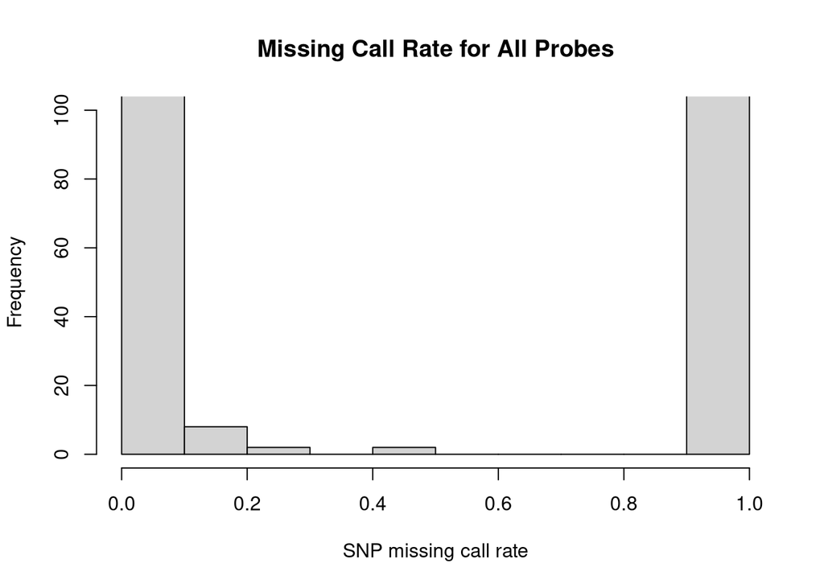

```r
#   Then go ahead and add missing.n1 as a new annotation data column, and update
#   the metadata

snpAnnot$missing.n1 <- miss$missing.fraction
varMetadata(snpAnnot)["missing.n1", "labelDescription"] <-
  paste(
    "fraction of genotype calls missing over all samples, except that females are excluded for Y chr SNPs"
  )

### Explore the missing call rate per probes a little more

#   Look at the distribution of missingness for all the probes

hist(
  snpAnnot$missing.n1,
  ylim = c(0, 100),
  xlab = "SNP missing call rate",
  main = "Missing Call Rate for All Probes"
)
```

```r
#   How many SNPs are missing a genotype for every single sample? Apparently
#   there are 151 such SNPs

sum(snpAnnot$missing.n1 == 1)
```

```
## [1] 151
```

```r
#   Store a vector containing the snpIDs of all the SNPs with missingness of
#   100%

snpexcl <- snpAnnot$snpID[snpAnnot$missing.n1 == 1]
```

Now we calculate and store `missing.e1`. The steps are described in the comments below.

```r
### Using missingGenotypeByScanChrom to calculate missing.e1

#   Apply missingGenotypeByScanChrom to genoData, using the snp.exclude option
#   to exclude these SNPs (why does it make sense to exclude those SNPs?)

miss <- missingGenotypeByScanChrom(genoData, snp.exclude = snpexcl)

#   Make sure the order of the scanIDs in the output from
#   missingGenotypeByScanChrom is the same as the order of the scanIDs in the
#   annotation data frame

allequal(names(miss$missing.fraction), scanAnnot$scanID)
```

```
## [1] TRUE
```

```r
#   Make a new column in scanAnnot called missing.e1 and store the per-scan
#   missingness from missingGenotypeByScanChrom there

scanAnnot$missing.e1 <- miss$missing.fraction

#   Update the scanAnnot metadata

varMetadata(scanAnnot)["missing.e1", "labelDescription"] <-
  "fraction of genotype calls missing over all snps with missing.n1<1 except that Y chr SNPs are excluded for females"

# We can check summary statistics and make a histogram, too

summary(scanAnnot$missing.e1)
```

```
##      Min.   1st Qu.    Median      Mean   3rd Qu.      Max.
## 0.0000000 0.0009656 0.0022229 0.0032162 0.0041283 0.0247827
```

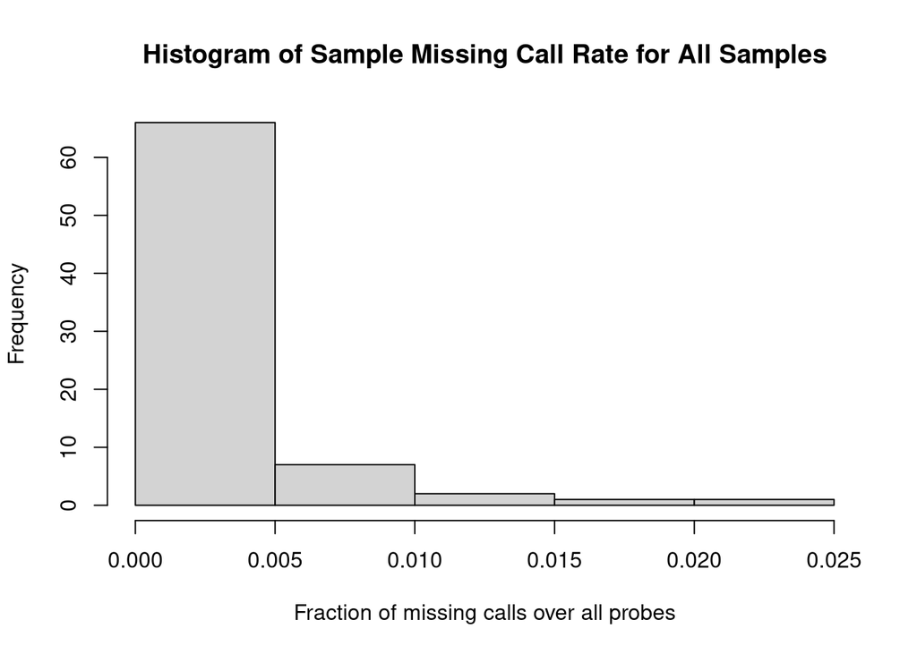

```r
hist(
  scanAnnot$missing.e1,
  xlab = "Fraction of missing calls over all probes",
  main = "Histogram of Sample Missing Call Rate for All Samples"
)
```

Now, supply your code to calculate and store `missing.n2`. The steps you should follow are described in the comments below.

```r
### Now that missing.n1 and missing.e1 have been calculated, we can calculate missing.n2

#   Recall that missing.n2 = missing call rate per SNP over all samples whose missing.e1
#   is less than 0.05.

#   Since no sample had missing.e1 > 0.05 in this dataset, we don't actually
#   have to exclude any samples.

#   However, let's proceed as if there were some samples with missing.e1 > 0.05.

#   Make a vector of the scanIDs for the samples with high missing.e1.

#   Apply the missingGenotypeBySnpSex function again, using the scan.exclude
#   argument.

#   Store missing.n2 as a new column in snpAnnot.

#   Update the metadata for snpAnnot!

#   The labelDescription for missing.n2 should be "fraction of genotype calls
#   missing over all samples with missing.e1 < 0.05 except that females are
#   excluded for Y chr SNPs"

#   <Your code goes here> ########################################

#   Make a vector of the scanIDs for the samples with high missing.e1.
snpexcl2 <- snpAnnot$snpID[snpAnnot$missing.e1 > 0.05]

#   Apply the missingGenotypeBySnpSex function again, using the scan.exclude
#   argument.
miss2 <- missingGenotypeBySnpSex(genoData, scan.exclude = snpexcl2)

#   Store missing.n2 as a new column in snpAnnot.
snpAnnot$missing.n2 <- miss2$missing.fraction

#   Update the metadata for snpAnnot!
varMetadata(snpAnnot)["missing.n2", "labelDescription"] <-
  "fraction of genotype calls missing over all samples with missing.e1 < 0.05 except that females are excluded for Y chr SNPs"

# should make a histogram to see also
summary(snpAnnot$missing.n2)
```

```
##    Min. 1st Qu.  Median    Mean 3rd Qu.    Max.
## 0.00000 0.00000 0.00000 0.04898 0.00000 1.00000
```

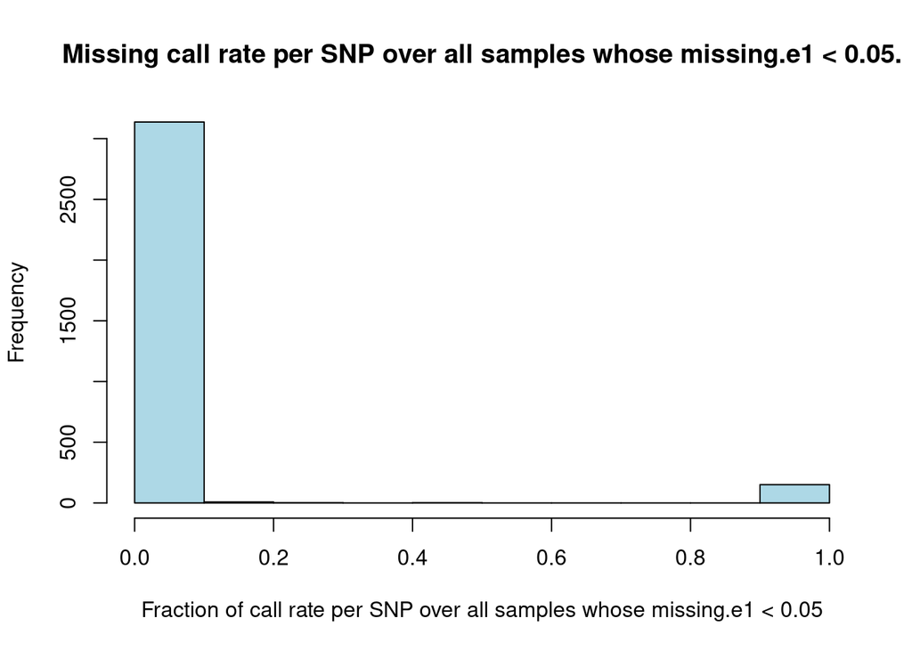

```r
hist(
  snpAnnot$missing.n2,
  xlab = "Fraction of call rate per SNP over all samples whose missing.e1 < 0.05",
  main = "Missing call rate per SNP over all samples whose missing.e1 < 0.05.",
  col = 'lightblue'
)
```

Write code to calculate and store `missing.e2`. The steps you should follow are described in the comments below.

```r
### Last, we calculate missing.e2

#   Recall missing.e2 = missing call rate per sample over all SNPs with
#   missing.n2 values less than 0.05

#   Store a vector with the snpIDs of all probes with missing.n2 >= 0.05

#   Apply missingGenotypeByScanChrom to genoData again, using the snp.exclude
#   argument to exclude the SNPs with missing.n2 >= 0.05 (why do we do this?)

#   Make a new column in scanAnnot called missing.e2 to store the missingness
#   per-scan you just calculated

#   Update the scanAnnot metadata

#   The labelDescription should say "fraction of genotype calls missing over all
#   snps with missing.n2 < 0.05 except that Y chr SNPs are excluded for females"

#   <Your code goes here> ########################################

#   Store a vector with the snpIDs of all probes with missing.n2 >= 0.05
snpexcl3 <- scanAnnot$snpID[scanAnnot$missing.n2 >= 0.05]

#   Apply missingGenotypeByScanChrom to genoData again, using the snp.exclude
#   argument to exclude the SNPs with missing.n2 >= 0.05 (why do we do this?)
miss3 <- missingGenotypeByScanChrom(genoData, snp.exclude = snpexcl3)

#   Make a new column in scanAnnot called missing.e2 to store the missingness
#   per-scan you just calculated
scanAnnot$missing.e2 <- miss$missing.fraction

#   Update the scanAnnot metadata
varMetadata(scanAnnot)["missing.e2", "labelDescription"] <-
  "fraction of genotype calls missing over all snps with missing.n2 < 0.05 except that Y chr SNPs are excluded for females"

# histogram
summary(scanAnnot$missing.e2)
```

```
##      Min.   1st Qu.    Median      Mean   3rd Qu.      Max.
## 0.0000000 0.0009656 0.0022229 0.0032162 0.0041283 0.0247827
```

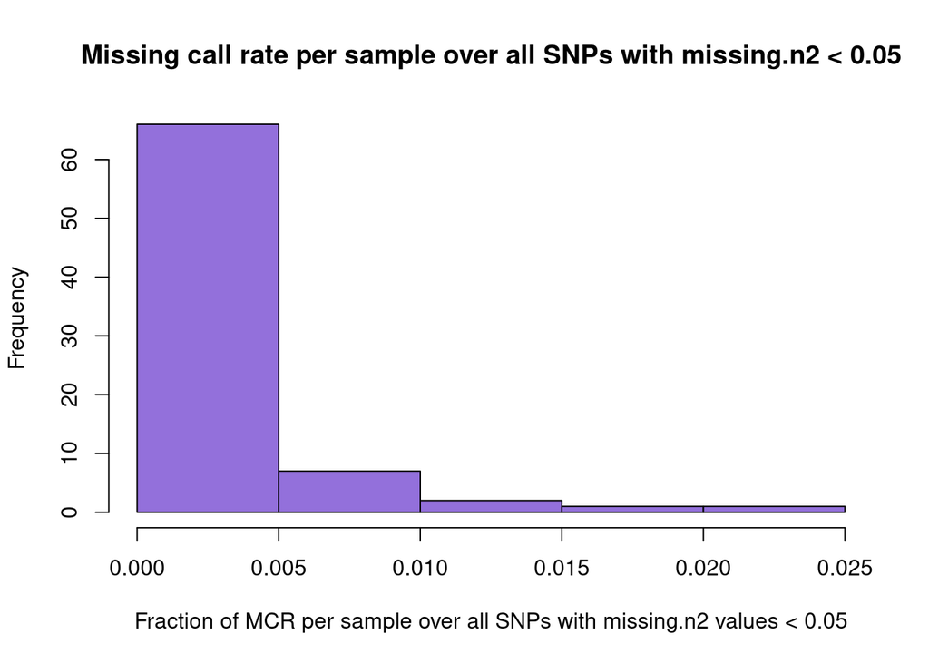

```r
hist(
  scanAnnot$missing.e2,
  xlab = "Fraction of MCR per sample over all SNPs with missing.n2 values < 0.05",
  main = "Missing call rate per sample over all SNPs with missing.n2 < 0.05",
  col = 'mediumpurple'
)
```

## Part 1 - Report

Summarize the filtering you’ve accomplished at this step. Include the following in your answer the following questions.

- (First, make sure you’ve filled in the calculations of `missing.n2` and `missing.e2` in the chunks above.)
- How many SNPs and samples were genotyped?
- Briefly describe the purpose of doing this step in two rounds (why do we calculate both missingnesses twice?)
- What were the median, mean, and maximum per-sample missingness (use `missing.e2`)? Make a histogram of `missing.e2`.
- How many samples had no missing calls at all (use `missing.e2`)?
- Are the samples generally “good”? How many should be excluded from downstream analyses?
- How many SNPs had a 100% missing call rate (use `missing.n1`)?
- What are the median, mean, and maximum per-SNP missingnesses (use `missing.n2`)? How many SNPs are missing no calls at all?
- Make a histogram of `missing.n2`.
- How many SNPs are filtered out and how many remain if you retain only SNPs with `missing.n2` < 0.05?
- Make a histogram showing `missing.n2` for the remaining SNPs.

```r
library(ggplot2)

#   <Your code goes here>
sc <- pData(scanAnnot) # e1, e2
sn <- pData(snpAnnot) # n1, n2
head(sc)
```

```
##   scanID subjectID family    father    mother CoriellID race sex status
## 1    280 200191449   1341         0         0   NA06985  CEU   F      1
## 2    281 200191449   1341         0         0   NA06985  CEU   F      1
## 3    282 200030290   1341 200099417 200191449   NA06991  CEU   F      0
## 4    283 200030290   1341 200099417 200191449   NA06991  CEU   F      0
## 5    284 200099417   1341         0         0   NA06993  CEU   M      1
## 6    285 200099417   1341         0         0   NA06993  CEU   M      1
##                                genoRunID          plate batch
## 1 WG1000993-DNAG10-CIDR_06985@1007850397 WG0052814-AMP2     A
## 2 WG1000992-DNAF10-CIDR_06985@1007850586 WG0061258-AMP2     A
## 3 WG1000970-DNAB11-CIDR_06991@1007850444 WG0061536-AMP2     B
## 4 WG1000969-DNAA11-CIDR_06991@1007850587 WG0053489-AMP2     A
## 5 WG1000972-DNAE10-CIDR_06993@1007850591 WG0060475-AMP2     C
## 6 WG1000971-DNAD10-CIDR_06993@1007850421 WG0061540-AMP2     B
##                      file  missing.e1  missing.e2
## 1 GENEVA_1M_HapMap_37.csv 0.001931123 0.001931123
## 2 GENEVA_1M_HapMap_58.csv 0.004184100 0.004184100
## 3  GENEVA_1M_HapMap_5.csv 0.004505954 0.004505954
## 4  GENEVA_1M_HapMap_3.csv 0.011264886 0.011264886
## 5 GENEVA_1M_HapMap_10.csv 0.001587806 0.001587806
## 6 GENEVA_1M_HapMap_71.csv 0.003493172 0.003493172
```

```r
head(sn)
```

```
##    snpID chromosome position      rsID alleleA alleleB  BeadSetID IntensityOnly
## 1 999447         21 13733610 rs3132407       A       G 1185447327             1
## 2 999465         21 13852569 rs2775671       T       C 1169708488             0
## 3 999493         21 14038583 rs2775018       T       C 1192445330             0
## 4 999512         21 14136579 rs3115511       T       C 1149617207             0
## 5 999561         21 14396024 rs2822404       T       C 1149961944             0
## 6 999567         21 14404476 rs1556276       A       G 1149617207             0
##           tAA       tAB       tBB       rAA       rAB       rBB missing.n1
## 1 0.013743570 0.3290431 0.9184624 1.5622030 1.5927530 1.6142590 1.00000000
## 2 0.063259460 0.5440393 0.9796721 0.4431986 0.4431986 0.4431986 0.01298701
## 3 0.001315146 0.2623954 0.5362323 2.6349810 2.3149340 2.0012760 0.06493506
## 4 0.011004820 0.5692499 0.9846884 0.8781826 0.9453412 0.8209958 0.00000000
## 5 0.040206810 0.5691788 0.9902423 1.0941700 1.1270790 0.9898759 0.00000000
## 6 0.030895730 0.6842008 0.9837771 0.5954081 0.7681253 0.7900150 0.00000000
##   missing.n2
## 1 1.00000000
## 2 0.01298701
## 3 0.06493506
## 4 0.00000000
## 5 0.00000000
## 6 0.00000000
```

```r
# How many SNPs and samples were genotyped?
sn %>%
  filter(missing.n1 != 1) %>%
  count() # 3149
```

```
##      n
## 1 3149
```

```r
# missing.e2 histogram
summary(scanAnnot$missing.e2)
```

```
##      Min.   1st Qu.    Median      Mean   3rd Qu.      Max.
## 0.0000000 0.0009656 0.0022229 0.0032162 0.0041283 0.0247827
```

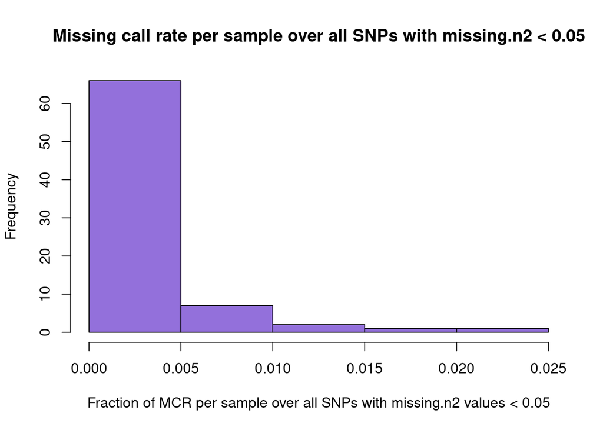

```r
hist(
  scanAnnot$missing.e2,
  xlab = "Fraction of MCR per sample over all SNPs with missing.n2 values < 0.05",
  main = "Missing call rate per sample over all SNPs with missing.n2 < 0.05",
  col = 'mediumpurple'
)
```

```r
# How many samples had no missing calls at all (use missing.e2)?
sc %>%
  filter(missing.e2 == 0) # 1? this doesn't seem right but I can't figure out why?
```

```
##   scanID subjectID family father mother CoriellID race sex status
## 1    321 200118596   1334      0      0   NA12144  CEU   M      1
##                                genoRunID          plate batch
## 1 WG1001172-DNAA08-CIDR_12144@1007850613 WG0063166-AMP2     C
##                      file missing.e1 missing.e2
## 1 GENEVA_1M_HapMap_74.csv          0          0
```

```r
# How many SNPs had a 100% missing call rate (use missing.n1)?
sn %>%
  filter(missing.n1 == 1) %>%
  count() # 151
```

```
##     n
## 1 151
```

```r
# missing.n2 histogram
summary(snpAnnot$missing.n2)
```

```
##    Min. 1st Qu.  Median    Mean 3rd Qu.    Max.
## 0.00000 0.00000 0.00000 0.04898 0.00000 1.00000
```

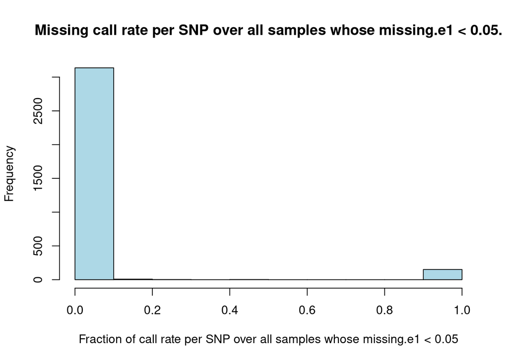

```r
hist(
  snpAnnot$missing.n2,
  xlab = "Fraction of call rate per SNP over all samples whose missing.e1 < 0.05",
  main = "Missing call rate per SNP over all samples whose missing.e1 < 0.05.",
  col = 'lightblue'
)
```

```r
# What are the median, mean, and maximum per-SNP missingnesses (use missing.n2)? How many SNPs are missing no calls at all?
sn %>%
  filter(missing.n2 == 0) %>%
  count() # 2755
```

```
##      n
## 1 2755
```

```r
# How many SNPs are filtered out and how many remain if you retain only SNPs with missing.n2 < 0.05?
sn %>%
  filter(missing.n2 < 0.05) %>%
  count() # 3095
```

```
##      n
## 1 3095
```

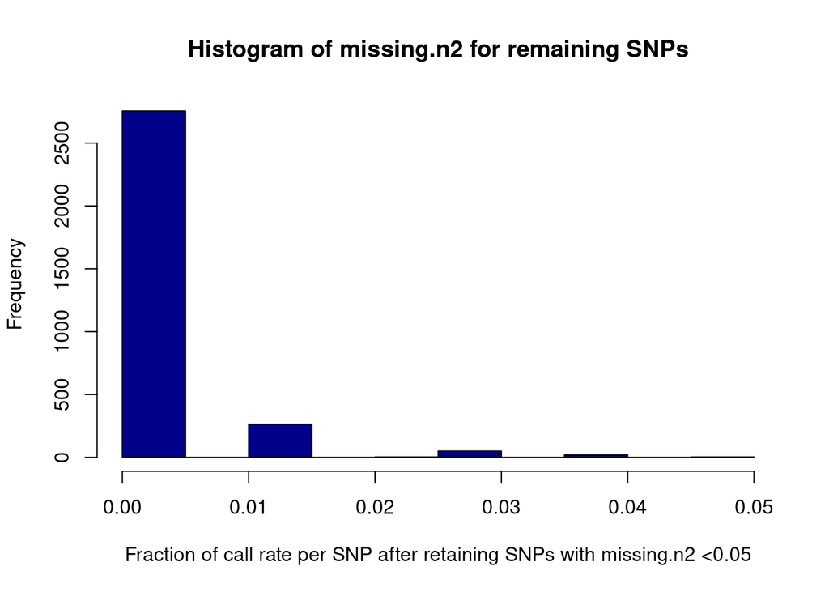

```r
# Make a histogram showing missing.n2 for the remaining SNPs.
hist(
sn$missing.n2[sn$missing.n2 < 0.05], # would be nice if base R cooperated with tidyverse
xlab = "Fraction of call rate per SNP after retaining SNPs with missing.n2 <0.05",
main = "Histogram of missing.n2 for remaining SNPs",
col = 'darkblue'
)
```

## Part 2 - Inferred vs. Reported Sex and Relatedness

To investigate discrepancies in inferred vs. reported sex (and, possibly, sex chromosome aneuploidies), we will produce four plots that summarize each scan’s heterozygosity and intensity for the sex chromosomes:

1. Mean Y chromosome vs. mean X chromosome intensity
2. Mean X chromosome heterozygosity vs. mean X chromosome intensity
3. Mean Y chromosome intensity vs. mean X chromosome heterozygosity
4. Mean X chromosome heterozygosity vs. autosomal heterozygosity

Recall that the intensity data was read in earlier as `qxyData`. Before making our graphs, we’ll need to calculate the variables we want to plot. The basic function we’ll use to do this is `meanIntensityByScanChrom()`, which will return a list of matrices. Read the help file of this function so that you understand the output. Heterozygosity is calculated with `hetByScanChrom()`.

```r
#   Look at the structure of the IntensityData object

qxyData
```

```
## An object of class IntensityData
##  | data:
## File: /software/rhel9/manual/install/r/4.5.0/lib64/R/library/GWASdata/extdata/illumina_qxy.gds (1.0M)
## +    [  ]
## |--+ sample.id   { Int32 77 ZIP(42.2%), 130B }
## |--+ snp.id   { Int32 3300 ZIP(38.5%), 5.0K }
## |--+ snp.chromosome   { UInt8 3300 ZIP(1.15%), 38B } *
## |--+ snp.position   { Int32 3300 ZIP(91.0%), 11.7K }
## |--+ snp.rs.id   { VStr8 3300 ZIP(38.4%), 12.5K }
## |--+ quality   { Float32 3300x77 ZIP(4.93%), 48.9K }
## |--+ X   { Float32 3300x77 ZIP(50.3%), 498.8K }
## \--+ Y   { Float32 3300x77 ZIP(49.4%), 490.5K }
##  | SNP Annotation:
## An object of class 'SnpAnnotationDataFrame'
##   snps: 1 2 ... 3300 (3300 total)
##   varLabels: snpID chromosome ... rBB (14 total)
##   varMetadata: labelDescription
##  | Scan Annotation:
## An object of class 'ScanAnnotationDataFrame'
##   scans: 1 2 ... 77 (77 total)
##   varLabels: scanID subjectID ... file (13 total)
##   varMetadata: labelDescription
```

```r
#   For each probe, there's a numerical ID, chromosome, position, rsID

#   The intensities (stored as variables called X and Y) are each essentially
#   3300×77 matrices (an X and Y intensity for each scan for every single probe)

#   (Don't confuse the *intensity variable names* _X_ and _Y_ in the IntensityData
#   object with the X and Y *chromosomes*!)

#   Apply the meanIntensityByScanChrom function to get the intensity averages.
#   (We're not going to use all of the output from this function)

inten.by.chrom <- meanIntensityByScanChrom(qxyData)

#   Extract the matrix containing the mean intensity for each chromosome for
#   each scan

names(inten.by.chrom)
```

```
## [1] "mean.intensity" "sd.intensity"   "mean.X"         "sd.X"
## [5] "mean.Y"         "sd.Y"
```

```r
mninten <- inten.by.chrom$mean.intensity

#   The matrix is 77x6 since there are 77 samples and 6 chromosomes represented
#   in the dataset

dim(mninten)
```

```
## [1] 77  6
```

```r
head(mninten)
```

```
##           21       22        X      XY         Y        M
## 280 1.145446 1.393316 1.118105 1.10446 0.2830108  3.54744
## 281 1.145529 1.378407 1.128745 1.09263 0.2774100  2.41541
## 282 1.139627 1.364754 1.122555 1.10036 0.3043980  4.55299
## 283 1.181063 1.475676 1.136374 1.16277 0.2789200 10.84578
## 284 1.177230 1.436911 0.730352 1.16742 0.9116500  3.38423
## 285 1.120587 1.387991 0.704766 1.09283 0.8304700  3.04392
```

```r
#   We also need to calculate the X chromosome and autosome heterozygosities for
#   each sample before we can plot them

#   Apply hetByScanChrom to genoData (we need actual genotypes to calculate the
#   heterozygosity)

het.results <- hetByScanChrom(genoData)

#   The function calculates eachs scan's heterozygosity for each chromosome, and
#   also for the autosomes as a whole

#   We want to add X and autosome heterozygosity as new columns in scanAnnot

#   Make sure the scanIDs are in the right order first! (they are)

allequal(scanAnnot$scanID, rownames(het.results))
```

```
## [1] TRUE
```

```r
#   Extract the autosomal and X heterozygosity and store them in scanAnnot

scanAnnot$het.A <- het.results[, "A"]
scanAnnot$het.X <- het.results[, "X"]

#   Add appropriate metadata

varMetadata(scanAnnot)["het.A", "labelDescription"] <-
  "fraction of heterozygotes for autosomal SNPs"
varMetadata(scanAnnot)["het.X", "labelDescription"] <-
  "fraction of heterozygotes for X chromosome SNPs"

#   Before making the plots, there are a few things to do

#   We want to color the plotted points by annotated sex

#   But first, make sure that the order of the scanIDs (and hence the annotated
#   sexes) matches the order of the scanIDs in the data we'll plot

allequal(scanAnnot$scanID, rownames(mninten))
```

```
## [1] TRUE
```

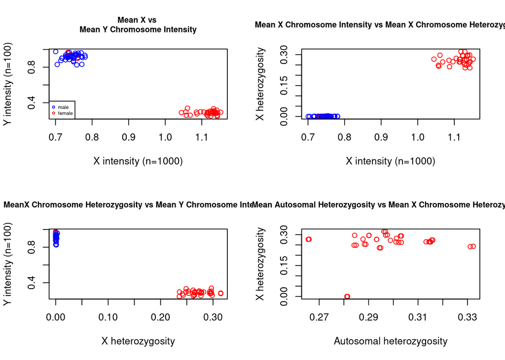

```r
#   Now we assign each sex a color (male=blue, female=red)

#   Store the colors in a vector

xcol <- rep(NA, nrow(scanAnnot))
xcol[scanAnnot$sex == "M"] <- "blue"
xcol[scanAnnot$sex == "F"] <- "red"

#   We also want to count the number of SNPs getting included on the X and Y
#   chromosomes (which are coded as 23 and 25 in snpAnnot)

nx <- sum(snpAnnot$chromosome == 23)
ny <- sum(snpAnnot$chromosome == 25)

# Now make the plots

# All intensities

x1 <- mninten[, "X"]
y1 <- mninten[, "Y"]
main1 <- "Mean X vs \nMean Y Chromosome Intensity"

# Het on X vs X intensity

x2 <- mninten[, "X"]
y2 <- scanAnnot$het.X
main2 <-
  "Mean X Chromosome Intensity vs Mean X Chromosome Heterozygosity"

# Het on X vs Y intensity

y3 <- mninten[, "Y"]
x3 <- scanAnnot$het.X
main3 <-
  "MeanX Chromosome Heterozygosity vs Mean Y Chromosome Intensity"

# X vs A het

x4 <- scanAnnot$het.A[scanAnnot$sex == "F"]
y4 <- scanAnnot$het.X[scanAnnot$sex == "F"]
main4 <-
  "Mean Autosomal Heterozygosity vs Mean X Chromosome Heterozygosity"

# Make labels for axes/legends

cols <- c("blue", "red")
mf <- c("male", "female")
xintenlab <- paste("X intensity (n=", nx, ")", sep = "")
yintenlab <- paste("Y intensity (n=", ny, ")", sep = "")

# Make the 4 plots and add a legend

par(mfrow = c(2, 2))
plot(
  x1,
  y1,
  xlab = xintenlab,
  ylab = yintenlab,
  main = main1,
  col = xcol,
  cex.main = 0.8
)
legend("bottomleft",
       mf,
       col = cols,
       pch = c(1, 1),
       cex = 0.5)
plot(
  x2,
  y2,
  col = xcol,
  xlab = xintenlab,
  ylab = "X heterozygosity",
  main = main2,
  cex.main = 0.8
)
plot(
  x3,
  y3,
  col = xcol,
  ylab = yintenlab,
  xlab = "X heterozygosity",
  main = main3,
  cex.main = 0.8
)
plot(
  x4,
  y4,
  col = "red",
  xlab = "Autosomal heterozygosity",
  ylab = "X heterozygosity",
  main = main4,
  cex.main = 0.8
)
```

```r
par(mfrow = c(1, 1))
```

## Part 2 - Report (Sex Check)

- Describe any anomalies you see in the 4 plots above.
- Figure out the scanIDs of any scans that look like outliers or possible instances of mislabeled sex. Include these IDs in your report and describe why they appear to be mislabeled.
- For the purposes of this assignment we will ASSUME that some scans have just had their sexes mislabeled. (In “real life”, we would not just assume this, and we might instead flag these scans for removal from some downstream steps/analyses.)
- Manually change the sex annotation for these scans in scanAnnot to “remove” the discrepancy. (Manually changing your data is risky and not generally recommended. Be careful!). In your report, state exactly what changes you made. Add a new column to scanAnnot indicating this, too (add appropriate metadata). Does anything in the pedigree structure make you more confident that this “fix” is correct? (Are these samples labeled as mothers or fathers?)
- Remake the 4 plots above, using the “corrected” data (nothing should appear mislabeled now for this dataset).
- How might you follow up on this “in real life”?

```r
#   <Your code goes here>
sc <- pData(scanAnnot)

# Figure out the scanIDs of any scans that look like outliers or possible instances of mislabeled sex.
sc %>%
  filter(het.X < 0.1 & sex == 'F') # 0.1 is a bit of an arbitrary threshold, but I looked at the graphs and saw that there was a significant gap around this area
```

```
##   scanID subjectID family father mother CoriellID race sex status
## 1    325 200094287   1408      0      0   NA12155  CEU   F      1
## 2    326 200094287   1408      0      0   NA12155  CEU   F      1
##                                genoRunID          plate batch
## 1 WG1000973-DNAD07-CIDR_12155@1007850404 WG0053513-AMP2     C
## 2 WG1000974-DNAE07-CIDR_12155@1007850413 WG0053492-AMP2     B
##                      file   missing.e1   missing.e2     het.A het.X
## 1 GENEVA_1M_HapMap_13.csv 0.0016092694 0.0016092694 0.2814852     0
## 2 GENEVA_1M_HapMap_17.csv 0.0003218539 0.0003218539 0.2812030     0
```

```r
# Manually change the sex annotation for these scans in scanAnnot to "remove" the discrepancy.
pData(scanAnnot)$sex[pData(scanAnnot)$sex == 'F' & pData(scanAnnot)$het.X < 0.1 ] <- 'M'
pData(scanAnnot) %>%
  filter(scanID == 325 | scanID == 326)
```

```
##   scanID subjectID family father mother CoriellID race sex status
## 1    325 200094287   1408      0      0   NA12155  CEU   M      1
## 2    326 200094287   1408      0      0   NA12155  CEU   M      1
##                                genoRunID          plate batch
## 1 WG1000973-DNAD07-CIDR_12155@1007850404 WG0053513-AMP2     C
## 2 WG1000974-DNAE07-CIDR_12155@1007850413 WG0053492-AMP2     B
##                      file   missing.e1   missing.e2     het.A het.X
## 1 GENEVA_1M_HapMap_13.csv 0.0016092694 0.0016092694 0.2814852     0
## 2 GENEVA_1M_HapMap_17.csv 0.0003218539 0.0003218539 0.2812030     0
```

```r
pData(scanAnnot) %>%
  filter(father == 200094287) # scanIDs listed above-- they're a father
```

```
##   scanID subjectID family    father    mother CoriellID race sex status
## 1    294 200074814   1408 200094287 200019401   NA10831  CEU   F      1
## 2    295 200074814   1408 200094287 200019401   NA10831  CEU   F      1
##                                genoRunID          plate batch
## 1 WG1000973-DNAB01-CIDR_10831@1007850378 WG0053511-AMP2     B
## 2 WG1000974-DNAC01-CIDR_10831@1007850368 WG0053490-AMP2     A
##                      file   missing.e1   missing.e2     het.A     het.X
## 1 GENEVA_1M_HapMap_11.csv 0.0009655616 0.0009655616 0.2943831 0.2360379
## 2 GENEVA_1M_HapMap_15.csv 0.0009655616 0.0009655616 0.2948847 0.2357895
```

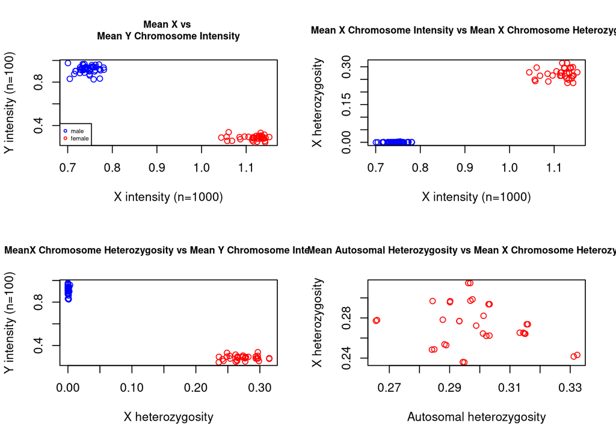

```r
# Remake the 4 plots above, using the "corrected" data (nothing should appear mislabeled now for this dataset).
#   Extract the matrix containing the mean intensity for each chromosome for
#   each scan
# names(inten.by.chrom)
# mninten <- inten.by.chrom$mean.intensity

#   Before making the plots, there are a few things to do

#   We want to color the plotted points by annotated sex
#   Now we assign each sex a color (male=blue, female=red)
#   Store the colors in a vector
xcol <- rep(NA, nrow(scanAnnot))
xcol[scanAnnot$sex == "M"] <- "blue"
xcol[scanAnnot$sex == "F"] <- "red"

#   We also want to count the number of SNPs getting included on the X and Y
#   chromosomes (which are coded as 23 and 25 in snpAnnot)
nx <- sum(snpAnnot$chromosome == 23)
ny <- sum(snpAnnot$chromosome == 25)

# Now make the plots

# All intensities
x1 <- mninten[, "X"]
y1 <- mninten[, "Y"]
main1 <- "Mean X vs \nMean Y Chromosome Intensity"

# Het on X vs X intensity
x2 <- mninten[, "X"]
y2 <- scanAnnot$het.X
main2 <-
  "Mean X Chromosome Intensity vs Mean X Chromosome Heterozygosity"

# Het on X vs Y intensity
y3 <- mninten[, "Y"]
x3 <- scanAnnot$het.X
main3 <-
  "MeanX Chromosome Heterozygosity vs Mean Y Chromosome Intensity"

# X vs A het
x4 <- scanAnnot$het.A[scanAnnot$sex == "F"]
y4 <- scanAnnot$het.X[scanAnnot$sex == "F"]
main4 <-
  "Mean Autosomal Heterozygosity vs Mean X Chromosome Heterozygosity"

# Make labels for axes/legends
cols <- c("blue", "red")
mf <- c("male", "female")
xintenlab <- paste("X intensity (n=", nx, ")", sep = "")
yintenlab <- paste("Y intensity (n=", ny, ")", sep = "")

# Make the 4 plots and add a legend
par(mfrow = c(2, 2))
plot(
  x1,
  y1,
  xlab = xintenlab,
  ylab = yintenlab,
  main = main1,
  col = xcol,
  cex.main = 0.8
)
legend("bottomleft",
       mf,
       col = cols,
       pch = c(1, 1),
       cex = 0.5)
plot(
  x2,
  y2,
  col = xcol,
  xlab = xintenlab,
  ylab = "X heterozygosity",
  main = main2,
  cex.main = 0.8
)
plot(
  x3,
  y3,
  col = xcol,
  ylab = yintenlab,
  xlab = "X heterozygosity",
  main = main3,
  cex.main = 0.8
)
plot(
  x4,
  y4,
  col = "red",
  xlab = "Autosomal heterozygosity",
  ylab = "X heterozygosity",
  main = main4,
  cex.main = 0.8
)
```

```r
par(mfrow = c(1, 1))
```

## Part 3 - Allelic Imbalance; BAF and LRR Plots

Here we want to look at B allele frequency (BAF) and log R ratio (LRR) plots using `chromIntensityPlot()`. Ordinarily, since there are 22 to 23 chromosomes to check for every sample, you would use a script that automatically detects aberrations in BAF and LRR. For this project, we’ll pretend that our pipeline has already flagged one sample for a possible chromosomal anomaly.

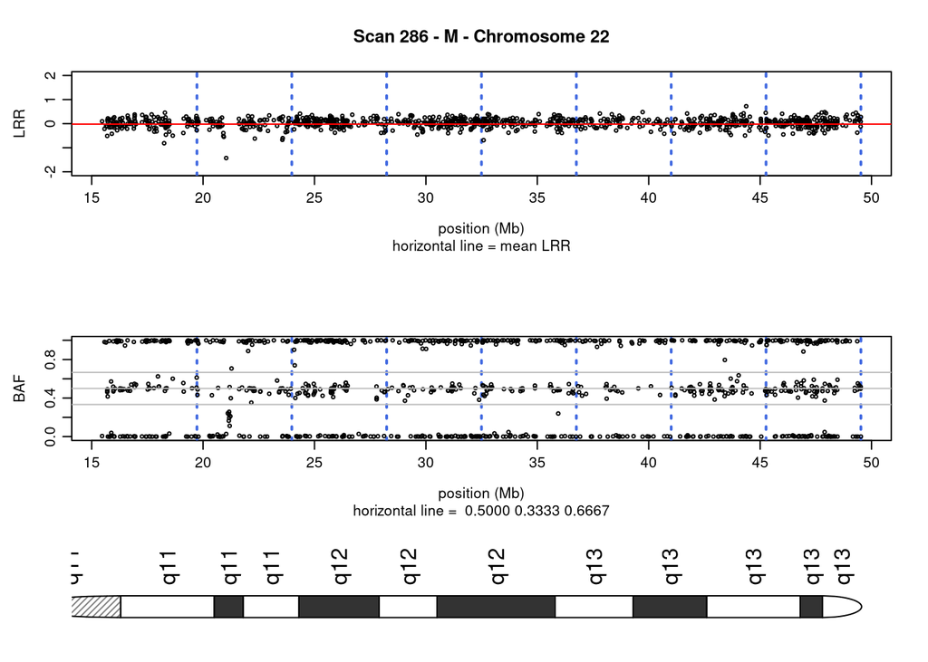

```r
# Recall that earlier we read the intensity data into an IntensityData object
# called blData.

# The snp/scan annotation were attached as well.

# Suppose that chromosome 22 was flagged for scanID 286.

# Making the BAF/LRR plot is easy

#dev.off()
chromIntensityPlot(blData, scan.ids = 286, chrom.ids = 22)
```

```r
par(mfrow = c(1, 1))
```

## Part 3 - Report

- Describe the purpose of this step.
- Show an example of a “normal” pair of BAF/LRR plots (choose any chromosome/scanID you want).
- How would you detect trisomy 21 (i.e., describe briefly in words what the BAF/LRR plot would look like).
- Suppose an individual had a balanced reciprocal translocation involving chromosome 2 and 4. What would you expect that individual’s BAF/LRR plots would look like for those chromosomes?
- Suppose chromosome 22 in sample 286 was the only chromosome flagged for a possible anomaly in this dataset. Looking at the plot, do you notice anything strange? Can you suggest what kind of anomaly might be showing up? (There isn’t any single answer that’s certainly right! The purpose of this question is to check that you understand what the BAF and LRR plots “mean”).
- Finally, suppose your pipeline has given you a list of the exact chromosomal segments showing possibly aneuploidies/anomalies in each sample. What would you recommend doing with the genotypes in those segments? (You’re not being asked to implement this here - just say what you recommend doing.)

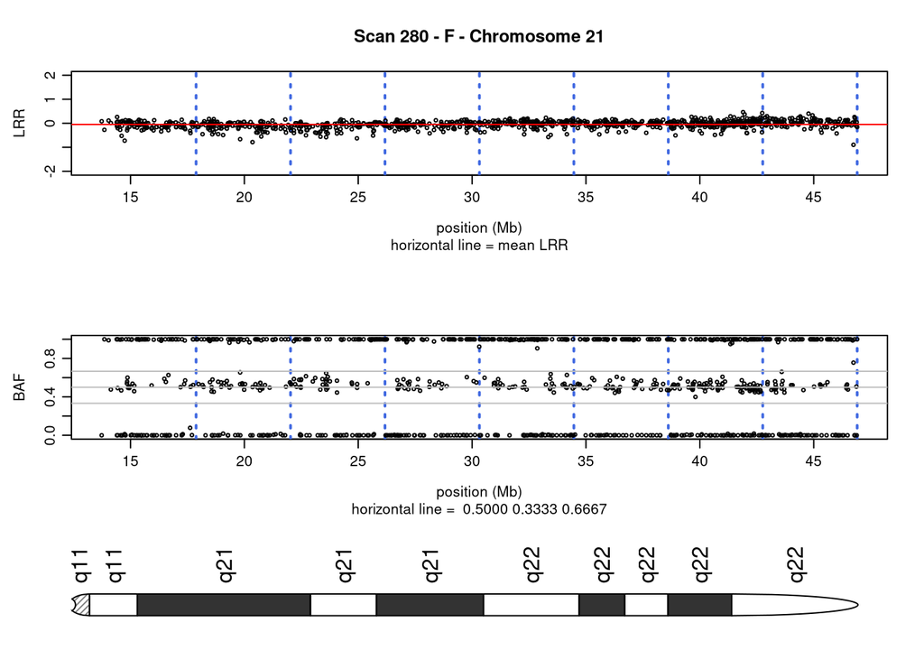

```r
#  <Your code goes here>
# Show an example of a "normal" pair of BAF/LRR plots (choose any chromosome/scanID you want).
chromIntensityPlot(blData, scan.ids = 280, chrom.ids = 21)
```

```r
par(mfrow = c(1, 1))
```